# Exploratory Analysis

Nicholas A. Yager

2015-02-20

## Introduction

For the UP-Stat data competition we are tasked to

> discover the most compelling, appealing and practical patterns in the episodes of traffic congestion. The merits will be measured in terms of novelty of the patterns discovered, usability of the recommendations made, and originality of the scientific methods used.

With that in mind, we need to know what we are working with. Our data have 5 variables:

- **Volume (vehicles/hour)**: the number of vehicles per hour going by the location. It is computed as twelve times the actual volume measured over five minutes. **This is also known as the flow, or flow rate.**
- **Speed** (miles/hour)**: calculated from the difference in time between the beginning and ending of vehicle detection. It is the average over all estimated speeds of detected vehicles within a five-minute window.
- **Delay (seconds)**: Estimate of how long vehicles wait between arrival at and departure from the intersection.
- **Stops** (vehicles/hour) count how many vehicles are approaching a red light. *It approximates the length of the queue when the light is red.*
- **DateTime**: Time coordinate of the data in the POSIX format “%m/%d/%y %H:%M”.

## Data Handling

Loading the data is trivial with the exception of the date data. Dates should be converted from a string into a Date object for easy subsetting.

```r
# Read the data ----------------------------------------------------------------
traffic <- read.csv("../../data/UrbanAnalytics2015.csv", sep=" ")

## Parse the datetime as a Date object.
traffic$DateTime <- strptime(traffic$DateTime, "%m/%d/%y %H:%M")
```

Let’s begin with examining the distributions for each variable.

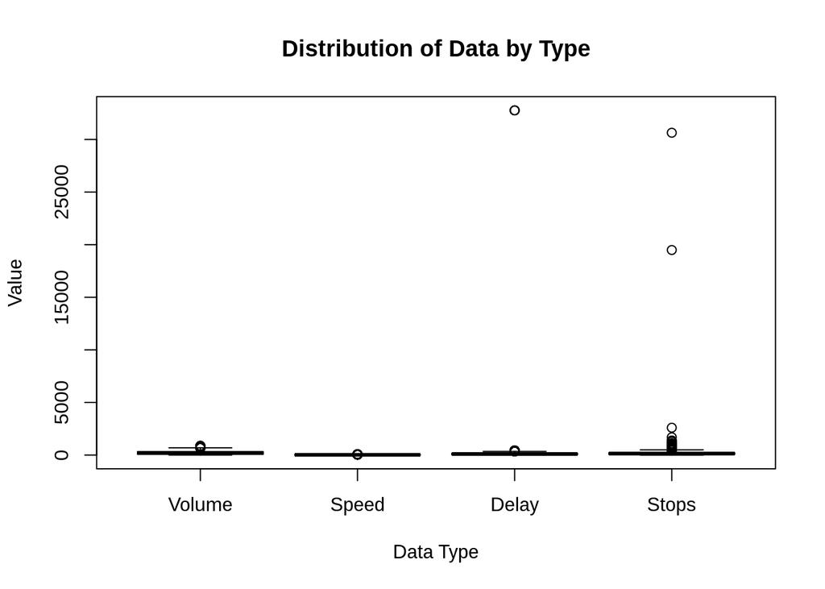

```r
# We can exclude the date
boxplot(traffic[1:4],
        main="Distribution of Data by Type",
        ylab="Value",
        xlab="Data Type")
```

Right from the get-go, it looks like there are some extreme outliers in the data. For the sake of statistical consistency, we can replace the rows with absurd outliers with NAs. For this rough exploration, let’s say any value greater than 5000 in an outlier.

```r
outliers.delay <- which(traffic$Delay > 5000)
traffic$Delay[outliers.delay] <- NA

outliers.stops <- which(traffic$Stops > 5000)
traffic$Stops[outliers.stops] <- NA
```

Now, let’s reexamine the distributions for our data.

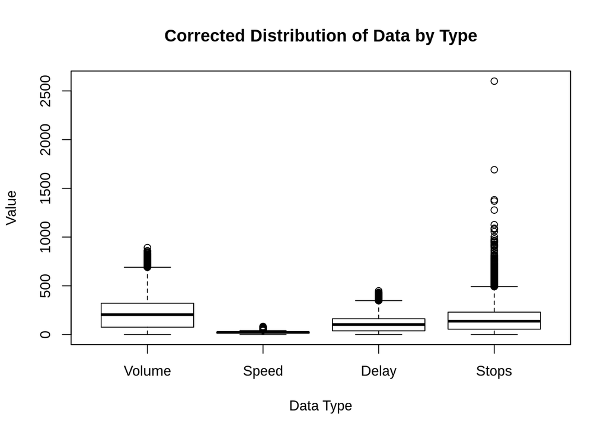

```r
# We can exclude the date
boxplot(traffic[1:4],
        main="Corrected Distribution of Data by Type",
        ylab="Value",
        xlab="Data Type")
```

Still odd, but not totally absurd. It looks like the Stops rate is very unevenly distributed, with observations over 1000 vehicles stopped per hour, which doesn’t seem right at face value. Of particular note is Speed, which has a consistent spread within typical legal ranges.

Let’s graph a pairing plot of each variable for one week, for instance.

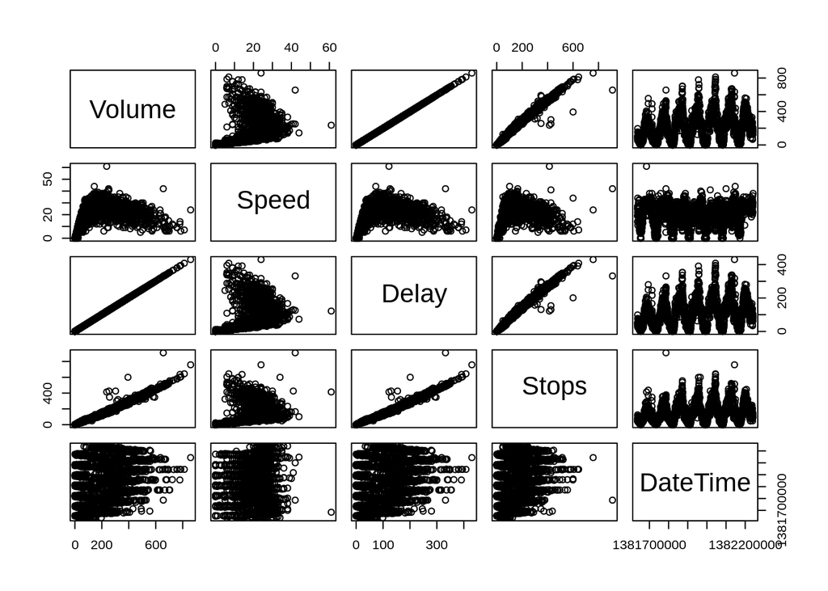

```r
daysToSteps <- function(days){
    return(days * (1440/5))
    }
plot(traffic[1:daysToSteps(7),])
```

Since we are interested in traffic congestion, it may be prudent to examine the delay times more in depth. This plot shows one week, Sunday through Saturday, from October, 2013. On most week days, the delay time increases as the day moves forward until characteristic rush hour times at which point the delay periods skyrocket. The one major exception to this is the Friday in this examples, which sees a sudden peak around 20:00.

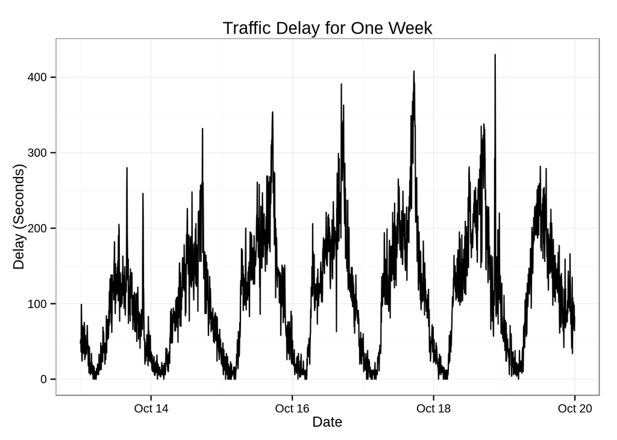

```r
ggplot(traffic[1:daysToSteps(7),], aes(x=DateTime,y=Delay))+
    geom_line() +
    labs(title = "Traffic Delay for One Week") +
    xlab("Date") +
    ylab("Delay (Seconds)")+
    theme_bw()
```

It may be useful to examine a detrended plot of delay, allowing for observing the overall changes in delay over time. In a detrended analysis, it’s easier to see the exact moments of large traffic influx. It may also be useful to perform a Fourier transformation to locate dominant frequencies in the delays.

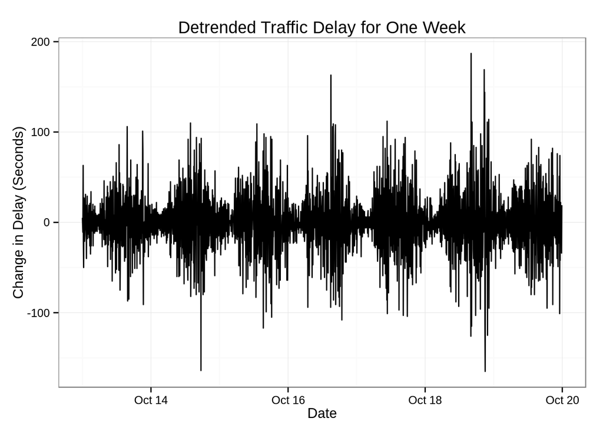

```r
diffs <- diff(traffic$Delay[1:daysToSteps(7)])
detrendedData <- data.frame(Delay <- diffs, Date = traffic$DateTime[1:(daysToSteps(7)-1)])
ggplot(detrendedData, aes(x=Date, y=Delay))+
    geom_line() +
    labs(title = "Detrended Traffic Delay for One Week") +
    xlab("Date") +
    ylab("Change in Delay (Seconds)")+
    theme_bw()
```

It seems like the most common times for delay are approximately the same time of day. This shows the aggregation of week day over the entire data set, with time increasing on the y-axis. The colors represent the average delay, with red having the least delay, and magenta having the most delay.

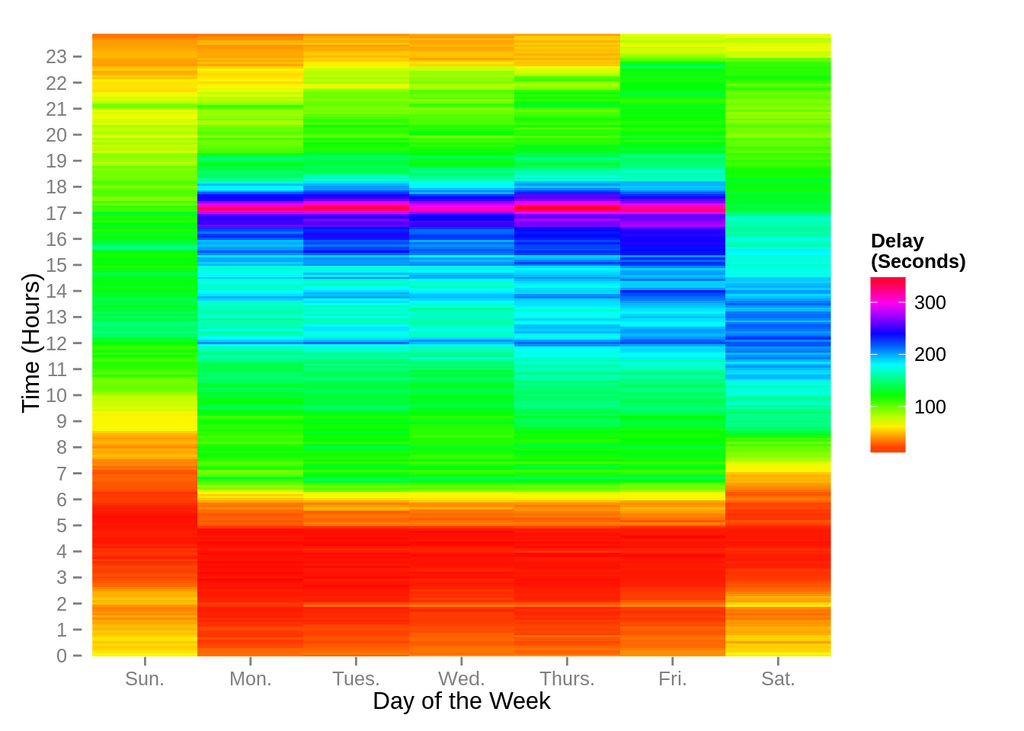

```r
# Aggregate averages over a day
stepsPerDay = daysToSteps(1)
dailyDelays <- matrix(0, nrow=7, ncol=stepsPerDay-1)
dailyCounts <- matrix(0, nrow=7, ncol=stepsPerDay-1)
for (index in 1:nrow(traffic)) {
    wDay = 1 + traffic$DateTime[index]$wday
    minute = (traffic$DateTime[index]$min + (traffic$DateTime[index]$hour * 60)) / 5
    if (! is.na(traffic$Delay[index])){
        dailyDelays[wDay, minute] = dailyDelays[wDay, minute] + traffic$Delay[index]
        dailyCounts[wDay, minute] = dailyCounts[wDay, minute] + 1
        }
    }

dailyDelays = dailyDelays / dailyCounts
dayList<-c("Sun.","Mon.","Tues.","Wed.","Thurs.","Fri.","Sat.")

ggplot(melt(dailyDelays), aes(Var1,Var2, fill=value)) +
    scale_fill_gradientn(colours=rainbow(50), name="Delay\n(Seconds)")+
    xlab("Day of the Week")+
    ylab("Time (Hours)")+
    geom_raster() +
    theme( panel.background = element_rect(fill = "transparent", colour = NA),
           panel.grid.minor = element_blank(),
           panel.grid.major = element_blank()) +
    scale_y_discrete(breaks = seq(1, 288, 12), labels = seq(0,23,1)) +
    scale_x_discrete(breaks=c("1","2","3","4","5","6","7"), labels=dayList,
                     limits=c(1,2,3,4,5,6,7))
```

And here is a colorblind friendly version, in which blue is low delay and orange is high delay.

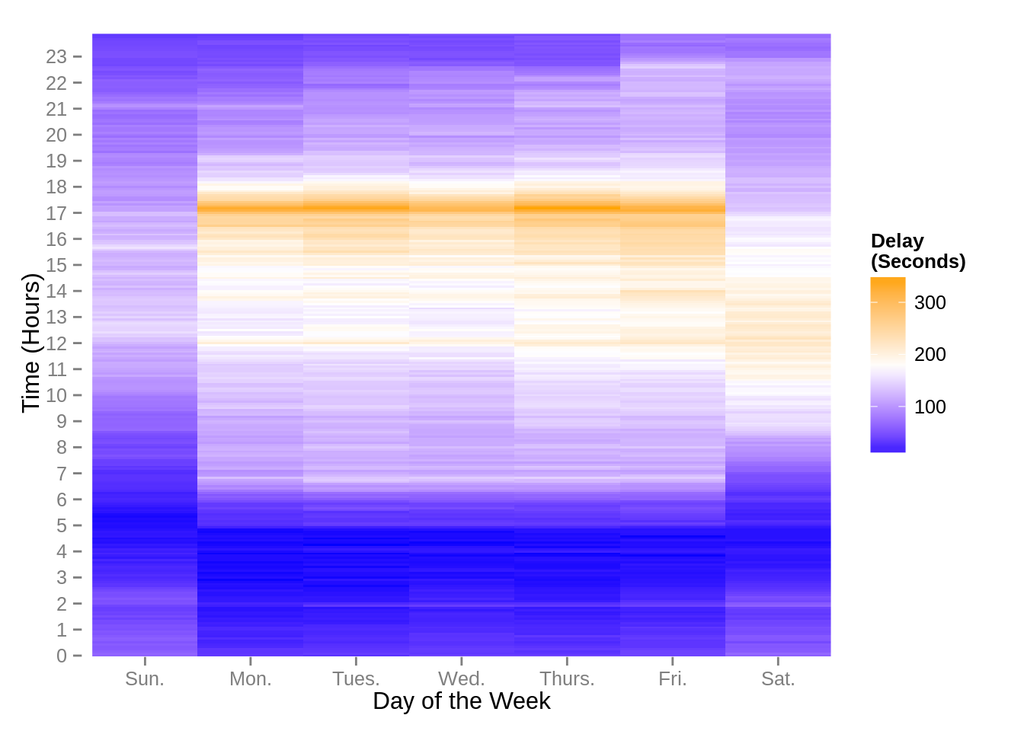

```r
ggplot(melt(dailyDelays), aes(Var1,Var2, fill=value)) +
    scale_fill_gradientn(colours=c("blue","white","orange"),name="Delay\n(Seconds)")+
    xlab("Day of the Week")+
    ylab("Time (Hours)")+
    geom_raster() +
    theme( panel.background = element_rect(fill = "transparent", colour = NA),
           panel.grid.minor = element_blank(),
           panel.grid.major = element_blank()) +
    scale_y_discrete(breaks = seq(1, 288, 12), labels = seq(0,23,1)) +
    scale_x_discrete(breaks=c("1","2","3","4","5","6","7"), labels=dayList,
                     limits=c(1,2,3,4,5,6,7))
```

Based on the work of Flynn *et al.*, you can quntify the critical density (vehicles/mile) for a traffic flow by comparing the relative density (density/maximum density) to the flow of the traffic. When traffic is below the critical density, if can flow around the traffic free flow rate determined by the road. When the density passes the critical value, the traffic breaks down into waves of congestion. As a result, the resulting traffic patterns flow with the wave flow rate, which is typically lower than the free flow rate.

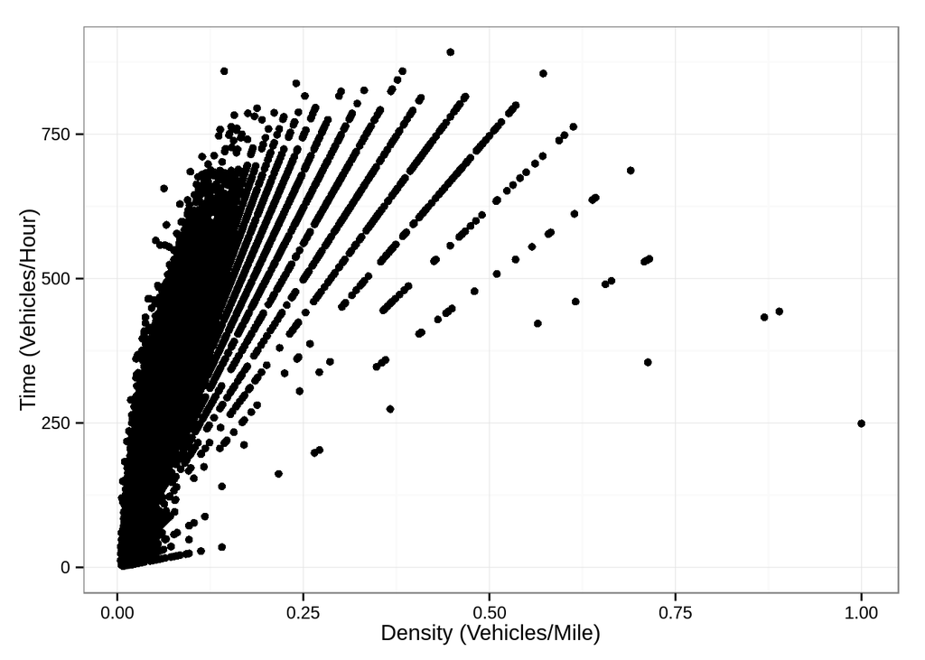

```r
# Density is described as q/v, where q is flow rate (volume), and v is average
# velocity
density = traffic$Volume/traffic$Speed

# Trim out non-finite values
density[which(!is.finite(density))]=NA

density.data <- data.frame(Density = density, Flow = traffic$Volume,relativeDensity=density/max(density,na.rm=T))

# Critical Density
Kc = density[which(traffic$Volume == max(traffic$Volume))] / max(density, na.rm=T)

# Density and flow -------------------------------------------------------------
# There is a non-linear relationship between the flow vs the density.
ggplot(density.data, aes(relativeDensity, Flow)) +
    geom_point() +
    xlab("Density (Vehicles/Mile)")+
    ylab("Time (Vehicles/Hour)") +
    theme_bw()
```

This is known as the fundamental diagram in traffic analysis, and can be used to detmermine at what speeds the traffice experiences free flow, unstable flow, traffic waves, and congestion.